# REM

```r
library(REM)
```

# Introduction

This vignette introduces the use of the robust expectation maximization (REM) algorithm; a statistical method for estimating the parameters of a latent variable model in the presence of population heterogeneity as suggested by Nieser & Cochran (2021).The REM algorithm is based on the expectation-maximization (EM) algorithm, but it allows for the case when not all the data are generated by the assumed data generating model.

# Data Description

```r
library(lavaan)
library(dplyr)
df <- HolzingerSwineford1939
head(df)
```

```
#>   id sex ageyr agemo  school grade       x1   x2    x3       x4   x5        x6
#> 1  1   1    13     1 Pasteur     7 3.333333 7.75 0.375 2.333333 5.75 1.2857143
#> 2  2   2    13     7 Pasteur     7 5.333333 5.25 2.125 1.666667 3.00 1.2857143
#> 3  3   2    13     1 Pasteur     7 4.500000 5.25 1.875 1.000000 1.75 0.4285714
#> 4  4   1    13     2 Pasteur     7 5.333333 7.75 3.000 2.666667 4.50 2.4285714
#> 5  5   2    12     2 Pasteur     7 4.833333 4.75 0.875 2.666667 4.00 2.5714286
#> 6  6   2    14     1 Pasteur     7 5.333333 5.00 2.250 1.000000 3.00 0.8571429
#>         x7   x8       x9
#> 1 3.391304 5.75 6.361111
#> 2 3.782609 6.25 7.916667
#> 3 3.260870 3.90 4.416667
#> 4 3.000000 5.30 4.861111
#> 5 3.695652 6.30 5.916667
#> 6 4.347826 6.65 7.500000
```

# Preprocessing

```r
data=df[,7:15]
```

# Modeling using REM for Exploratory Factor Analysis

The REM_EFA function, which is used for exploratory factor analysis requires data in a matrix form, to specify the k_range and the delta. The k_range is a vector with the range of number of factors that you want to model. In model below, the algorithm will perform exploratory data analysis for 2, 3 and 4 factors. Additionally, the delta parameter is a hyperparameter between 0 and 1 that captures the researcher’s tolerance of incorrectly down-weighting data from the model. The output of the model will contain three different lists, each one for the number of factors being considered respectively.

```r
model_EFA = REM_EFA( X = data, k_range = 2:4, delta = 0.05)
```

[output not shown]

# The summary function

The summary function selects the optimal model using the lowest score of Bayesian Information Criterion (BIC) from the number of factors considered. In this case, it selects the optimal model after considering the BIC in the models with 2, 3 and 4 factors.

```r
summary(model_EFA)
```

```
#> Optimal number of factor is:  3
#> $call
#> REM_EFA(X = data, k_range = 2:4, delta = 0.05)
#>
#> $optimal
#> [1] 3
#>
#> $EM
#>    Intercept   Factor 1    Factor 2    Factor 3   Res Var
#> x1  4.234926 0.27705961  0.62271514  0.15144563 0.5125280
#> x2  5.179137 0.10454341  0.48951552 -0.02663557 0.7487358
#> x3  1.993107 0.03371534  0.66264574  0.13034375 0.5427744
#> x4  2.633762 0.82690516  0.16517185  0.09875773 0.2791930
#> x5  3.369123 0.86099578  0.08653106  0.09122133 0.2428773
#> x6  1.998179 0.80115302  0.21240611  0.08844021 0.3052158
#> x7  3.848319 0.09056004 -0.07269579  0.69592084 0.5022084
#> x8  5.467310 0.05072775  0.16178947  0.70901420 0.4685497
#> x9  5.334255 0.13166715  0.40637199  0.52371639 0.5432467
#>
#> $REM
#>    Intercept   Factor 1    Factor 2    Factor 3   Res Var
#> x1  4.903723 0.27970918  0.74876165  0.09807419 0.3515002
#> x2  5.653243 0.13813761  0.38715412 -0.05564640 0.8279332
#> x3  2.050016 0.00646820  0.53797768  0.13170459 0.6931921
#> x4  2.875322 0.79708024  0.24404843  0.09863028 0.2953755
#> x5  3.527243 0.87999213  0.10347686  0.07559650 0.2091916
#> x6  2.257982 0.81228837  0.16195373  0.09825055 0.3043054
#> x7  3.893778 0.08780068 -0.07005311  0.72293935 0.4647423
#> x8  5.846151 0.04640945  0.08940486  0.73802020 0.4451791
#> x9  5.729626 0.12659388  0.40792039  0.55492056 0.5096381
#>
#> $epsilon
#> [1] 9.044389e-07
#>
#> $gamma
#> [1] 0.8453484
#>
#> $diff
#>      Intercept     Factor 1     Factor 2      Factor 3       Res Var
#> x1 -0.66879694 -0.002649570 -0.126046506  0.0533714456  0.1610278215
#> x2 -0.47410547 -0.033594203  0.102361402  0.0290108255 -0.0791973909
#> x3 -0.05690900  0.027247144  0.124668062 -0.0013608396 -0.1504176757
#> x4 -0.24156016  0.029824918 -0.078876577  0.0001274576 -0.0161824951
#> x5 -0.15811955 -0.018996347 -0.016945796  0.0156248364  0.0336857442
#> x6 -0.25980292 -0.011135343  0.050452381 -0.0098103409  0.0009103781
#> x7 -0.04545881  0.002759355 -0.002642680 -0.0270185133  0.0374660927
#> x8 -0.37884146  0.004318297  0.072384615 -0.0290060004  0.0233706080
#> x9 -0.39537065  0.005073265 -0.001548403 -0.0312041722  0.0336085991
#>
#> attr(,"class")
#> [1] "summary.REM"
```

## Plot Distribution of the weights

We want to know what is the distribution of the weights to know how much people are getting down-weighted.

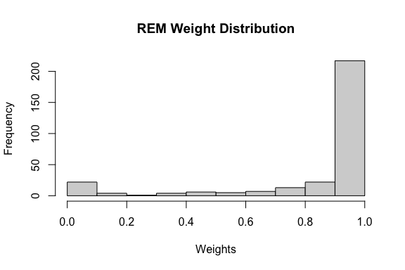

```r
hist(model_EFA[[2]]$REM_output$weights,main="REM Weight Distribution",xlab = "Weights", ylab = "Frequency")
```

## Compare EM and REM Estimates

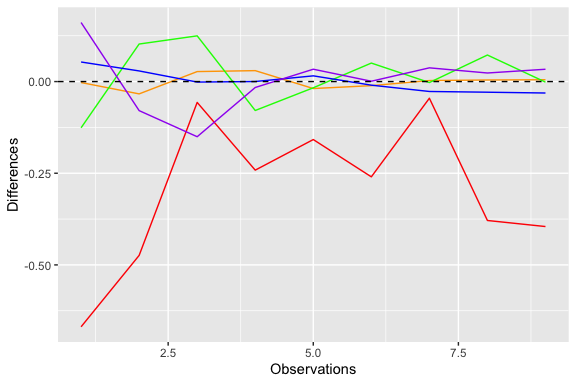

```r
library(dplyr)
library(ggplot2)

 x <- model_EFA
  k <- vector()
  j = length(x) - 1
  BIC <- vector(length = j)

  for (i in 1:j) {
    k[i] = x[[i]]$k
    BIC[i] = x[[i]]$BIC_rem
  }

  idx = which.min(BIC)
  optimal = x[[idx]]$k
  epsilon = x[[idx]]$epsilon
  gamma = x[[idx]]$REM_output$gamma
  EM <- cbind(x[[idx]]$EM_output$nu,x[[idx]]$EM_output$lambda,x[[idx]]$EM_output$psi)
  REM <- cbind(x[[idx]]$REM_output$nu,x[[idx]]$REM_output$lambda,x[[idx]]$REM_output$psi)

  colnames(REM) <- c("Intercept",paste("Factor",1:k[idx]),"Res Var")
  colnames(EM) <- c("Intercept",paste("Factor",1:k[idx]),"Res Var")


  ans <- x["call"]
  ans$optimal <-  optimal
  ans$EM <- EM
  ans$REM <- REM
  ans$epsilon <- epsilon
  ans$gamma <- gamma
  class(ans) <- "summary.REM"

diff = as.data.frame(ans$EM-ans$REM)
diff_plot <- ggplot(diff, aes(1:nrow(diff)),) +
    geom_line(aes(y = diff$Intercept), color = "red") +
    geom_line(aes(y = diff$`Factor 1`), color = "orange") +
    geom_line(aes(y = diff$`Factor 2`), color = "green") +
    geom_line(aes(y = diff$`Factor 3`), color = "blue") +
    geom_line(aes(y = diff$`Res Var`), color = "purple") +
    geom_hline(aes(yintercept=0),colour="black", linetype="dashed") +
    xlab("Observations") +
    ylab("Differences")

diff_plot
```

## Confirmatory Factor Analysis

From the previous section we determine that the optimal number of factors should be three. For this reason, we will model a confirmatory factor analysis using the function REM_CFA using three factors (k = 3). In this case we need to specify X (numeric dataframe considered), k (number of factors for the confirmatory factor analysis), delta (hyper-parameter) and constraints (p x k matrix of constraints).

```r
set.seed(1)
cons = matrix(nrow = ncol(data),ncol = 3)
cons[,1] = 1
cons[,2] = as.numeric(rbinom(ncol(data),1,0.5))
cons[,3] = 1
cons
```

```
#>       [,1] [,2] [,3]
#>  [1,]    1    0    1
#>  [2,]    1    0    1
#>  [3,]    1    1    1
#>  [4,]    1    1    1
#>  [5,]    1    0    1
#>  [6,]    1    1    1
#>  [7,]    1    1    1
#>  [8,]    1    1    1
#>  [9,]    1    1    1
```

```r
model_CFA = REM_CFA(X = data,k=3,delta = 0.05,constraints = cons)
```

[output not shown]

```r
model_CFA
```

```
#> $k
#> [1] 3
#>
#> $EM_output
#> $EM_output$nu
#>       x1       x2       x3       x4       x5       x6       x7       x8
#> 4.234926 5.179137 1.993107 2.633762 3.369123 1.998179 3.848319 5.467310
#>       x9
#> 5.334255
#>
#> $EM_output$lambda
#>       Factor1     Factor2     Factor3
#> x1 0.33110481  0.00000000 0.626128330
#> x2 0.13362016  0.00000000 0.454341899
#> x3 0.09066141 -0.04449415 0.667028704
#> x4 0.84149612  0.01107119 0.113552476
#> x5 0.87008318  0.00000000 0.027200414
#> x6 0.81788029  0.01726684 0.157528008
#> x7 0.16026928 -0.67096078 0.004573995
#> x8 0.13849873 -0.69013288 0.233925255
#> x9 0.21434147 -0.45485957 0.450473328
#>
#> $EM_output$psi
#>        x1        x2        x3        x4        x5        x6        x7        x8
#> 0.4983329 0.7757191 0.5448735 0.2788675 0.2422154 0.3059586 0.5241045 0.4498137
#>        x9
#> 0.5442343
#>
#> $EM_output$ind_lik
#>   [1] -18.222584 -14.549331 -11.102200 -10.065408 -11.131380 -14.120376
#>   [7] -12.259162 -11.840454 -14.772040 -10.233422  -9.299389 -10.185375
#>  [13] -13.653315 -14.881176 -11.735707 -12.181982 -10.722152  -9.529223
#>  [19] -11.405073 -12.141632 -12.803523 -13.173870  -9.536169 -12.673385
#>  [25] -11.172028 -14.530462 -14.361726 -11.658662 -17.214567 -10.936807
#>  [31] -10.737581 -12.343315 -10.506321 -11.064895 -11.603565 -13.038459
#>  [37] -10.444728 -12.685247 -14.224763 -10.820108  -9.024024 -11.193024
#>  [43] -13.978469 -10.550383 -13.712570 -13.013781 -17.743684 -14.032321
#>  [49] -10.970628 -11.050395 -12.746662 -12.086022 -13.583332 -10.262345
#>  [55] -12.206661  -9.382448 -10.810848 -12.363529 -10.388223 -10.852733
#>  [61]  -9.486408 -11.333677 -12.093212 -10.085813 -12.497380 -10.886051
```

[output cut: 133 more lines]

```
#> $REM_output$lik_rem
#> [1] -3646.915
#>
#> $REM_output$lik
#> [1] -3757.733
#>
#>
#> $epsilon
#> [1] 8.836277e-07
#>
#> $AIC_rem
#> [1] 7455.83
#>
#> $BIC_rem
#> [1] 7756.106
```